# 20260823_model

2026-08-23

# Contents

1. Hypotheses
2. Model Structure
3. Data Exploration
4. Model run
5. Validation and Verification

# (1) Hypotheses

The aim of this study is to assess whether there is an interactive effect between the intrinsic variation within the agroforestry system and the landscape heterogeneity on crop yield. And if there is one, then how does it shape the crop yield.

Hence, follwoing hypotheses are posed: H1: If in-field heterogeneity is included in the regional yield model, then the model will perform better (lower AIC) than the model that does not include the in-field complexity term. H2: How does the interactive effect or the separate effect of those differ between fields included in this analysis and what affects the shift between those.

# (2) Model Structure

In order to adress the named hypotheses the following model was designed. The model is built to assess the effects of surrounding landscape, intrinsic spatial variation and field characteristica of the field (as environmental, design and management specifics) on field’s agroforestry yield performance and follows the following srtucture:

*yield_tha ~ landscape heterogeneity (swf) + intrinsic variaton + field design*

(1.1) landscape heterogeneity the effect of landscape heterogeneity is assessed throught the availability of small woody features around the field as studies show that those have an effect on yields performance. as in Galpern et al 2020 the approach of functional predictor is implemented as it is still unclear at what distance does the surrounding landscape has the biggest effect on yield an this possibly depends on field special characteristica. Hence, borrowing from Galpern et al pethodology refund:pfr function is implemented to model this relation.

(1.2) intrisic variation fields intrinsic variation is represented by the distance at which the sample of the yield was taken, agroforestry research suggests that the yield in agroforestry system depends on the distance of the crops sample to the tree line. the effect is modeled by a smooth function as it is not linear ans is scalar.

(1.3) field characteristica field characteristica are specific for each field an hence act as bias correction. such are fields environmental conditions, soil t4exture, age of the agroforestry system and the trees within it.

# (3) Data Exploration

Following the Zuur et al protocol from 2010 the following data exploration procedure wqas completed: - outlier screening - distribution/homogeneity of the response - zero-inflation - collinearity - relationships - independence of observations

## Matrices for every group and subgroup

```r
df <- read.csv("C:\\Users\\Elizaveta/OneDrive - Universität Bayreuth\\Dokumente\\MasterThesis\\MA_RProject\\data\\AnalysisData\\20260823_full.csv")
```

```r
# ---- Numeric Variables  ----
num_vars <- c("prop_swf",
              "l_contag", "l_np", "l_sidi", "l_shdi", "l_ai", "l_ed",
              "distance_to_tree_strip",
              "temp_C_mean", "sun_MJ_m2_mean", "precip_mm_sum",
              "clay", "sand", "silt",
              "mean_slope", "min_slope", "max_slope" ,
              "prop_swf_within", "fert_N", "treeage", "AFage", "area")

# ---- Surrounding landscape heterogeneity: small woody features  ----
swf <- df |>
  dplyr::select(id, distance, swf_year, prop_swf) |>
  unique() |>
  pivot_wider(names_from = distance, values_from = prop_swf) |>
  arrange(id)

id_order <- swf$id
swf_mat    <- as.matrix(swf[, -c(1, 2)])
grid     <- as.numeric(colnames(swf_mat))


# ---- Surrounding landscape heterogeneity: landscape metrics ----
landscape_metrics <- df |>
  dplyr::select(id, l_contag, l_np, l_sidi, l_shdi, l_ai, l_ed) |>
  unique() |>
  arrange(id)

id_lm <- landscape_metrics$id
lm_mat    <- as.matrix(landscape_metrics[, -c(1)])
lm_cols     <- as.character(colnames(lm_mat))

stopifnot(id_order == id_lm)

# ---- In-field spatial variation ----
intrinsic_variation <- df |>
  dplyr::select(id, distance_to_tree_strip) |>
  unique() |>
  arrange(id)

id_iv <- intrinsic_variation$id
iv_mat    <- as.matrix(intrinsic_variation[, -c(1)])
iv_cols     <- as.character(colnames(iv_mat))

stopifnot(id_order == id_iv)

# ---- Environmental: climatic variables ----
climatic <- df |>
  dplyr::select(id, precip_mm_sum, sun_MJ_m2_mean, temp_C_mean) |>
  unique() |>
  arrange(id)

id_c <- climatic$id
c_mat    <- as.matrix(climatic[, -c(1)])
c_cols     <- as.numeric(colnames(c_mat))

stopifnot(id_order == id_c)

# ---- Environmental: soil ----
# adjust clay/silt/sand column names to match your dataset
soil <- df |>
  dplyr::select(id, clay, silt, sand) |>
  unique() |>
  arrange(id)

id_s <- soil$id
s_mat    <- as.matrix(soil[, -c(1)])
s_cols     <- as.character(colnames(s_mat))

stopifnot(id_order == id_s)

# ---- Environmental: elevation ----
elevation <- df |>
  dplyr::select(id, mean_slope, min_slope, max_slope) |>
  unique() |>
  arrange(id)

id_el <- elevation$id
el_mat    <- as.matrix(elevation[, -c(1)])
el_cols     <- as.character(colnames(el_mat))

stopifnot(id_order == id_el)

# ---- Field design ----
field_design <- df |>
  dplyr::select(id, prop_swf_within, fert_N, treeage, AFage, area) |>
  unique() |>
  arrange(id)

id_fd <- field_design$id
fd_mat    <- as.matrix(field_design[, -c(1)])
fd_cols     <- as.character(colnames(fd_mat))

stopifnot(id_order == id_fd)


# ---- Identifiers ----
identifiers <- df |>
  dplyr::select(id, field) |>
  unique() |>
  arrange(id)


namestemplate <- c("# ---- Surrounding landscape heterogeneity: small woody features  ----",
                   "swf, id_order, swf_mat, grid",
                   "# ---- Surrounding landscape heterogeneity: landscape metrics ----",
                   "landscape_metrics, id_lm, lm_mat, lm_cols",
                   "# ---- In-field spatial variation ----",
                   "intrinsic_variation, id_iv, iv_mat, iv_cols",
                    "# ---- Environmental: climatic variables ---- ",
                   "climatic, id_c, c_mat, c_cols",
                   " # ---- Environmental: soil ---- ",
                   "soil, id_s, s_mat, s_cols",
                    "# ---- Environmental: elevation ---- ",
                   "elevation, id_el, el_mat, el_cols ",
                    "# ---- Field design ---- ",
                    "field_design, id_fd, fd_mat, fd_cols",
                    "# ---- Identifiers ----",
                    "identifiers")
```

## Outliers

No outliers detected.

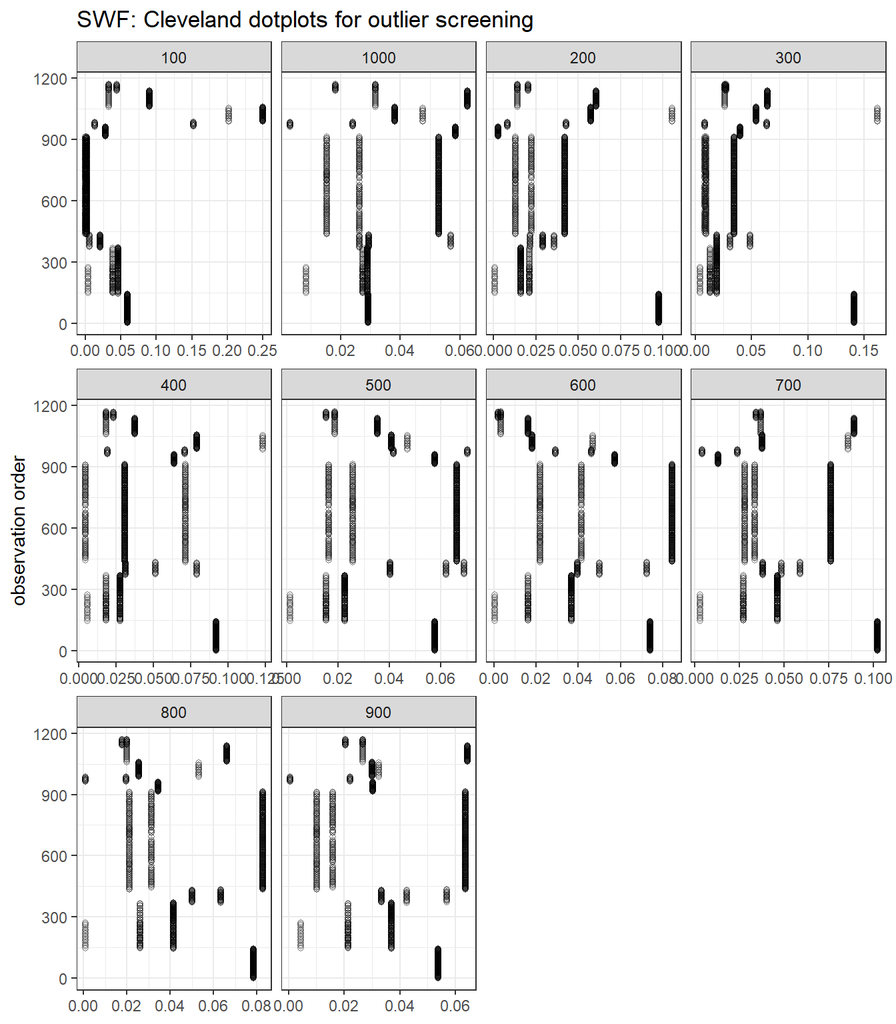

```r
# namestemplate

# ---- Surrounding landscape heterogeneity: small woody features  ----"
swf |>
  select(-c(1,2)) |>
  mutate(row = row_number()) |>
  pivot_longer(-row, names_to = "variable", values_to = "value") |>
  ggplot(aes(x = value, y = row)) +
  geom_point(shape = 1, alpha = 0.5) +
  facet_wrap(~variable, scales = "free_x") +
  theme_bw() +
  labs(y = "observation order", x = NULL,
       title = "SWF: Cleveland dotplots for outlier screening")
```

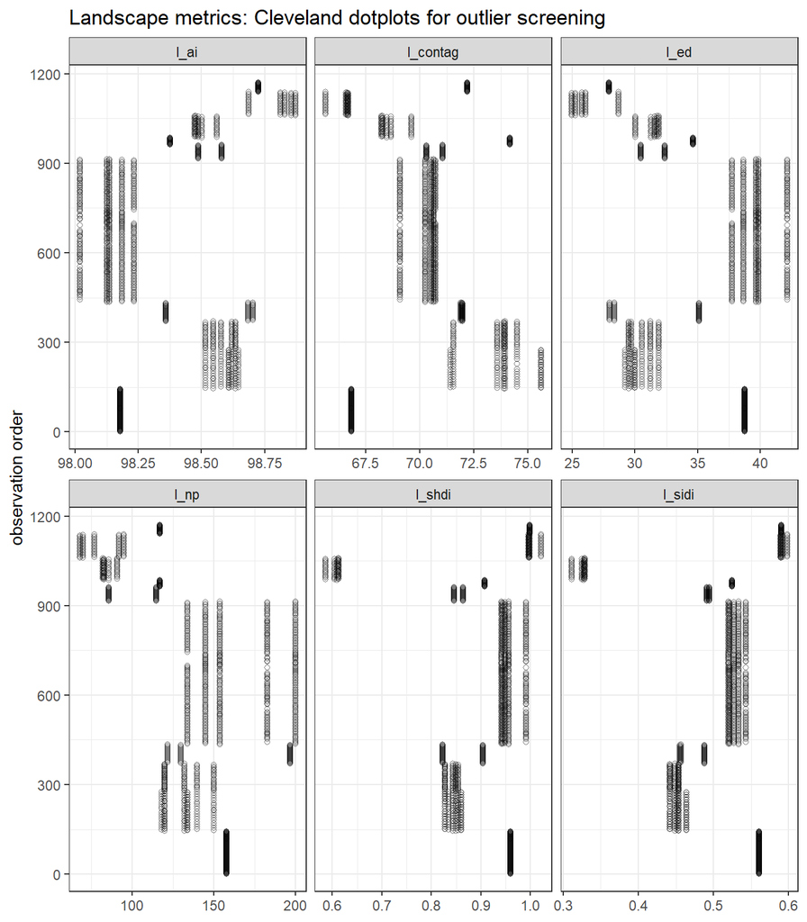

```r
# # ---- Surrounding landscape heterogeneity: landscape metrics ----
landscape_metrics |>
  select(-c(1)) |>
  mutate(row = row_number()) |>
  pivot_longer(-row, names_to = "variable", values_to = "value") |>
  ggplot(aes(x = value, y = row)) +
  geom_point(shape = 1, alpha = 0.5) +
  facet_wrap(~variable, scales = "free_x") +
  theme_bw() +
  labs(y = "observation order", x = NULL,
       title = "Landscape metrics: Cleveland dotplots for outlier screening")
```

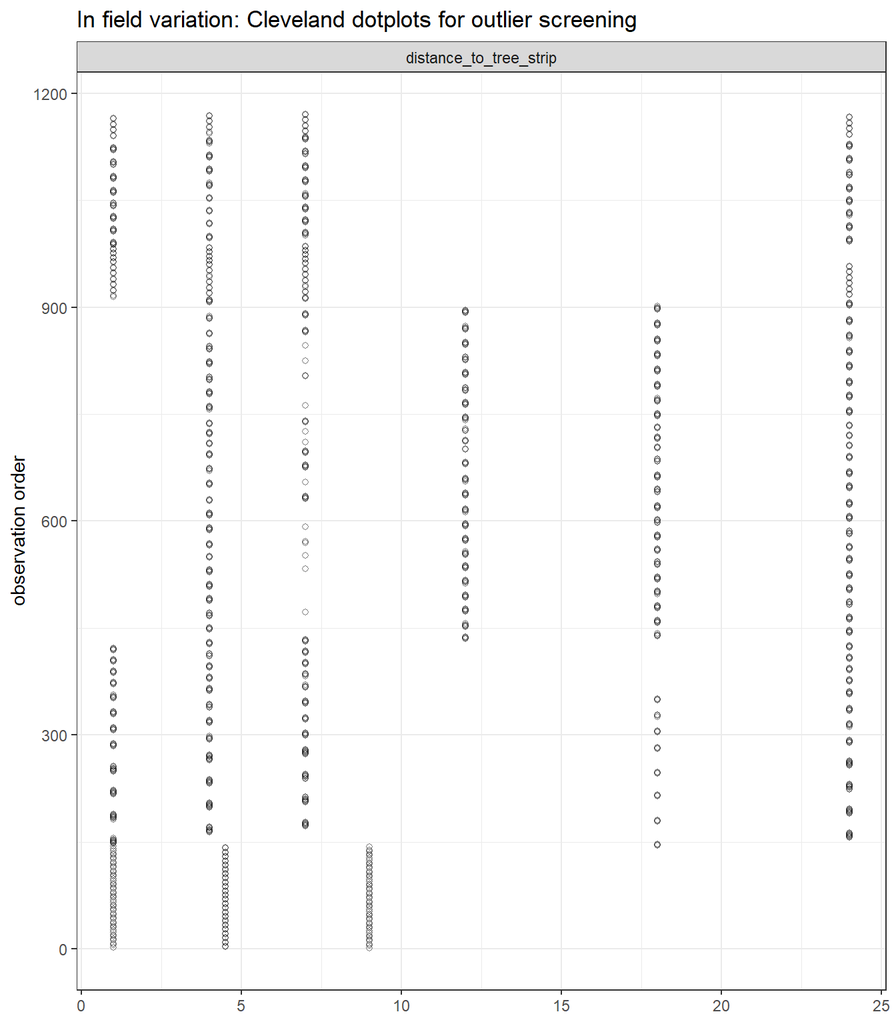

```r
# # ---- In-field spatial variation ----
intrinsic_variation |>
  select(-c(1)) |>
  mutate(row = row_number()) |>
  pivot_longer(-row, names_to = "variable", values_to = "value") |>
  ggplot(aes(x = value, y = row)) +
  geom_point(shape = 1, alpha = 0.5) +
  facet_wrap(~variable, scales = "free_x") +
  theme_bw() +
  labs(y = "observation order", x = NULL,
       title = "In field variation: Cleveland dotplots for outlier screening")
```

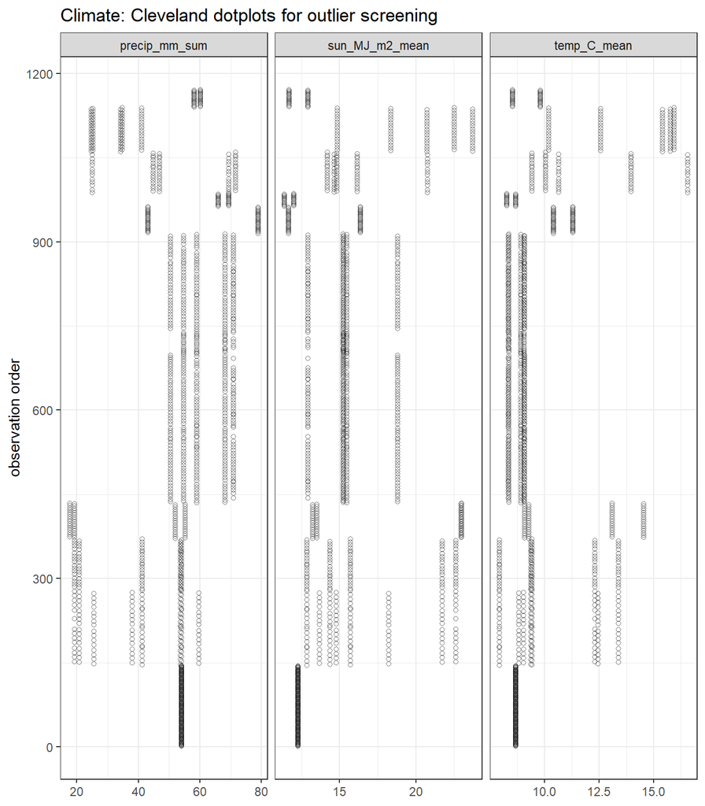

```r
# # ---- Environmental: climatic variables ----
climatic |>
  select(-c(1)) |>
  mutate(row = row_number()) |>
  pivot_longer(-row, names_to = "variable", values_to = "value") |>
  ggplot(aes(x = value, y = row)) +
  geom_point(shape = 1, alpha = 0.5) +
  facet_wrap(~variable, scales = "free_x") +
  theme_bw() +
  labs(y = "observation order", x = NULL,
       title = "Climate: Cleveland dotplots for outlier screening")
```

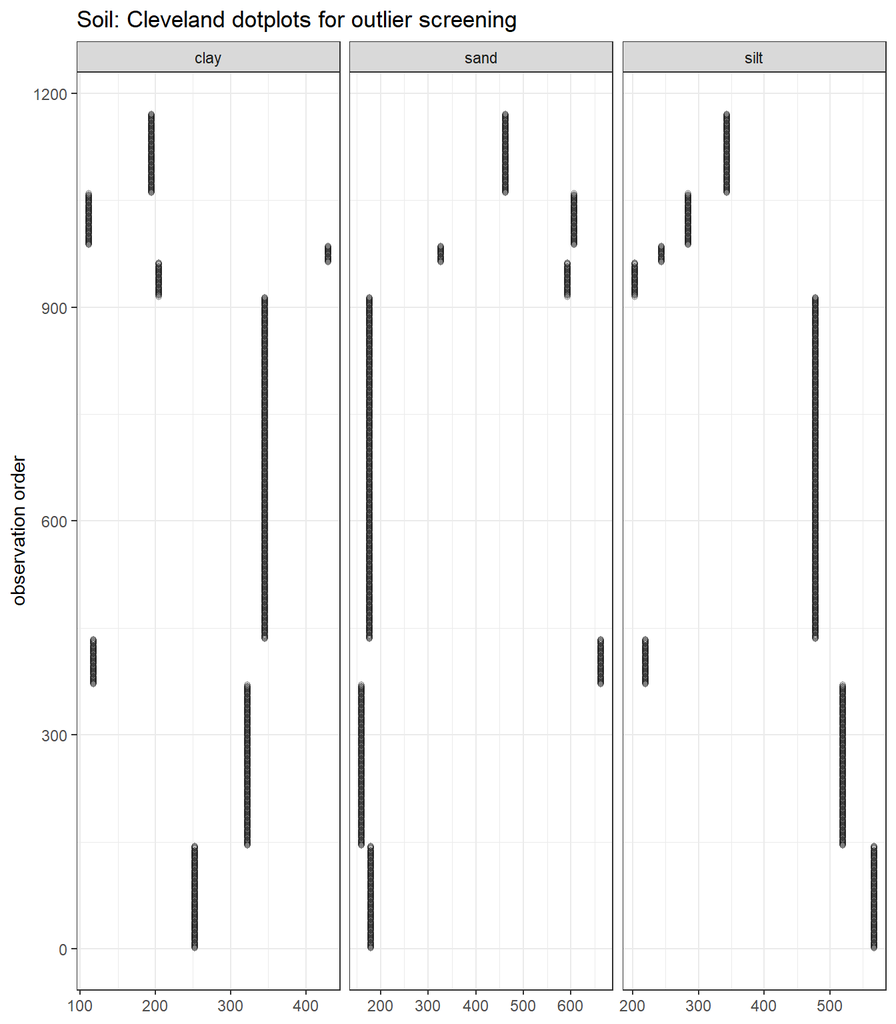

```r
# # ---- Environmental: soil ----
soil |>
  select(-c(1)) |>
  mutate(row = row_number()) |>
  pivot_longer(-row, names_to = "variable", values_to = "value") |>
  ggplot(aes(x = value, y = row)) +
  geom_point(shape = 1, alpha = 0.5) +
  facet_wrap(~variable, scales = "free_x") +
  theme_bw() +
  labs(y = "observation order", x = NULL,
       title = "Soil: Cleveland dotplots for outlier screening")
```

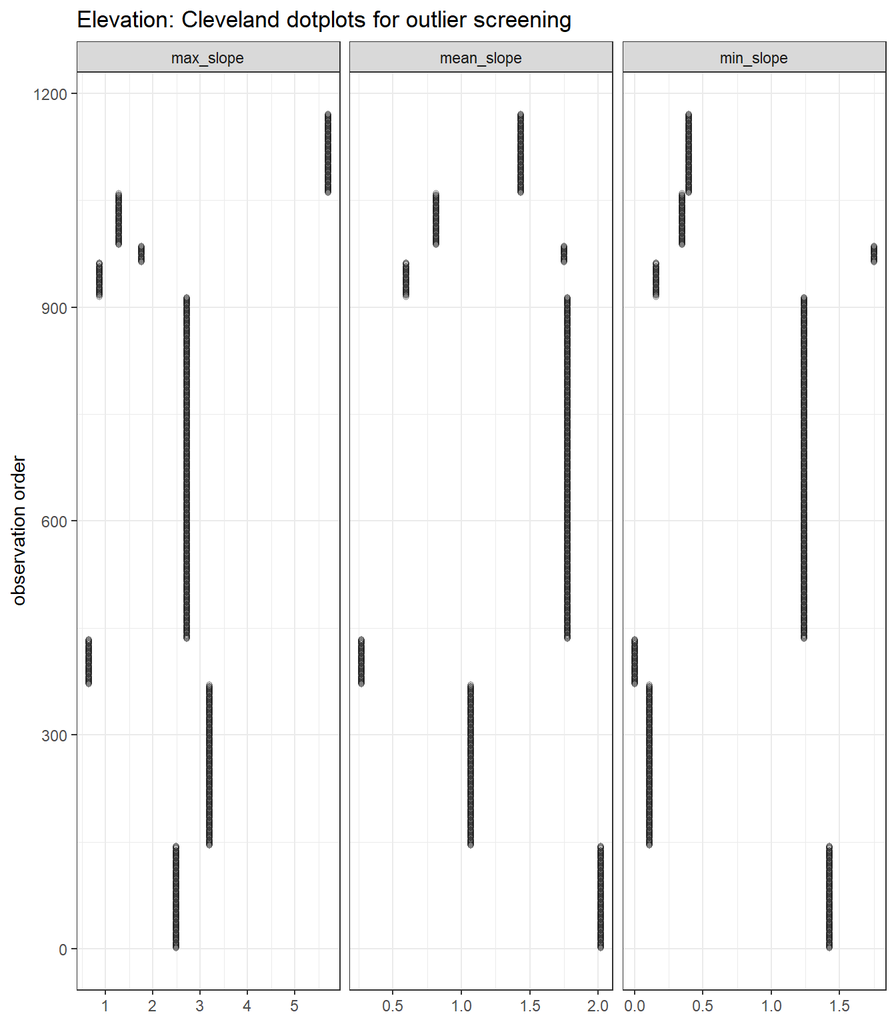

```r
# # ---- Environmental: elevation ----
elevation |>
  select(-c(1)) |>
  mutate(row = row_number()) |>
  pivot_longer(-row, names_to = "variable", values_to = "value") |>
  ggplot(aes(x = value, y = row)) +
  geom_point(shape = 1, alpha = 0.5) +
  facet_wrap(~variable, scales = "free_x") +
  theme_bw() +
  labs(y = "observation order", x = NULL,
       title = "Elevation: Cleveland dotplots for outlier screening")
```

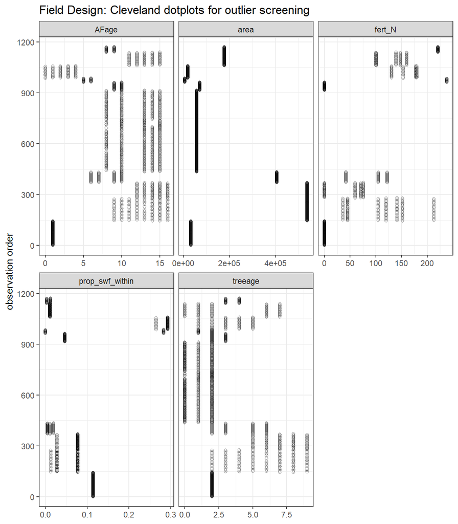

```r
# # ---- Field designn ----
field_design |>
  select(-c(1)) |>
  mutate(row = row_number()) |>
  pivot_longer(-row, names_to = "variable", values_to = "value") |>
  ggplot(aes(x = value, y = row)) +
  geom_point(shape = 1, alpha = 0.5) +
  facet_wrap(~variable, scales = "free_x") +
  theme_bw() +
  labs(y = "observation order", x = NULL,
       title = "Field Design: Cleveland dotplots for outlier screening")
```

## Distribution of the response variable: yield tha

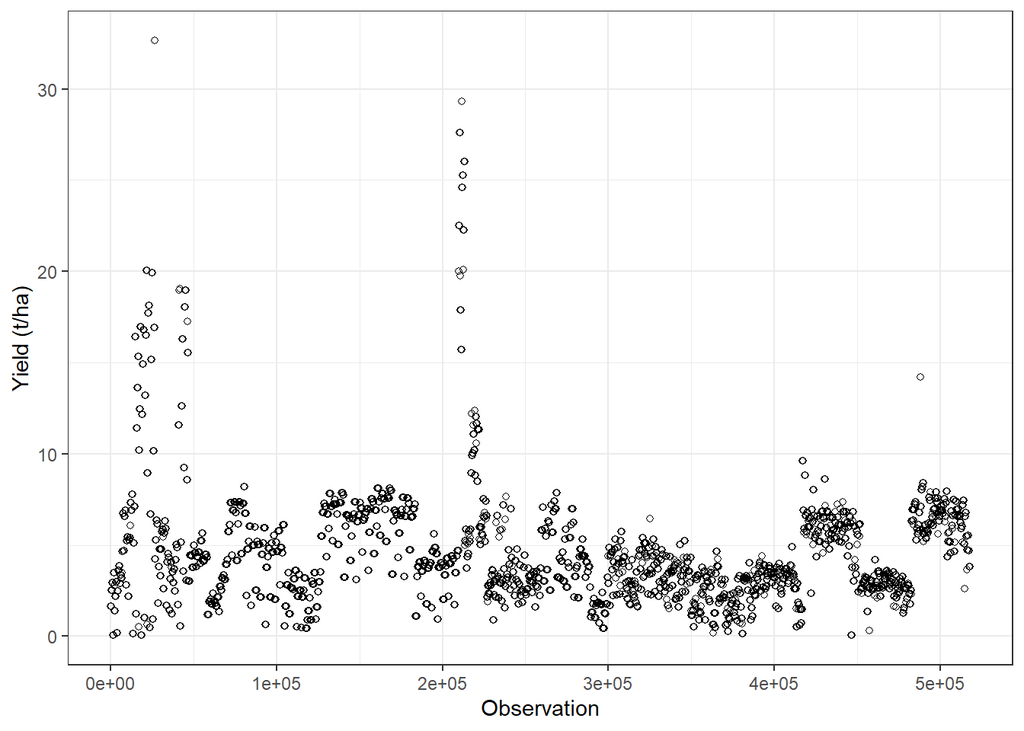

```r
ggplot(df, aes(x = seq_along(yield_tha), y = yield_tha)) +
  geom_point(shape = 1, alpha = 0.5) +
  theme_bw() +
  labs(
    x = "Observation",
    y = "Yield (t/ha)"
  )
```

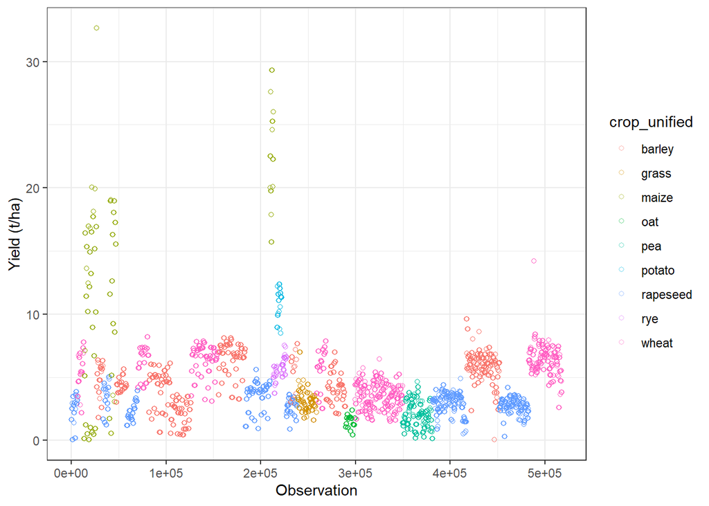

```r
ggplot(df, aes(x = seq_along(yield_tha), y = yield_tha, color = crop_unified)) +
  geom_point(shape = 1, alpha = 0.5) +
  theme_bw() +
  labs(
    x = "Observation",
    y = "Yield (t/ha)"
  )
```

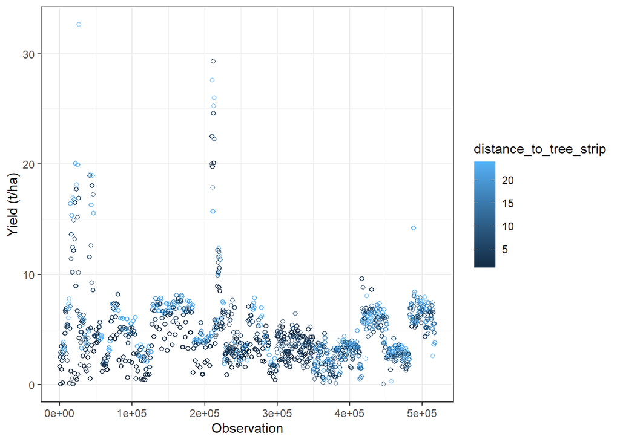

```r
ggplot(df, aes(x = seq_along(yield_tha), y = yield_tha, color = distance_to_tree_strip)) +
  geom_point(shape = 1, alpha = 0.5) +
  theme_bw() +
  labs(
    x = "Observation",
    y = "Yield (t/ha)"
  )
```

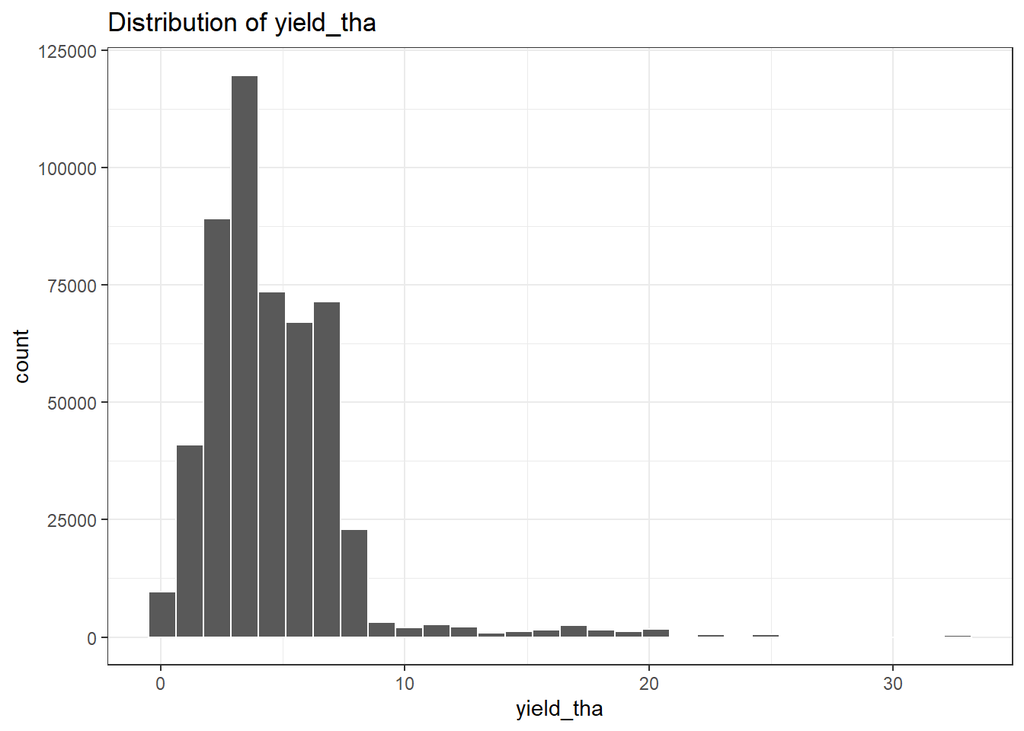

```r
ggplot(df, aes(x = yield_tha)) +
  geom_histogram(bins = 30, colour = "white") +
  theme_bw() +
  labs(title = "Distribution of yield_tha")
```

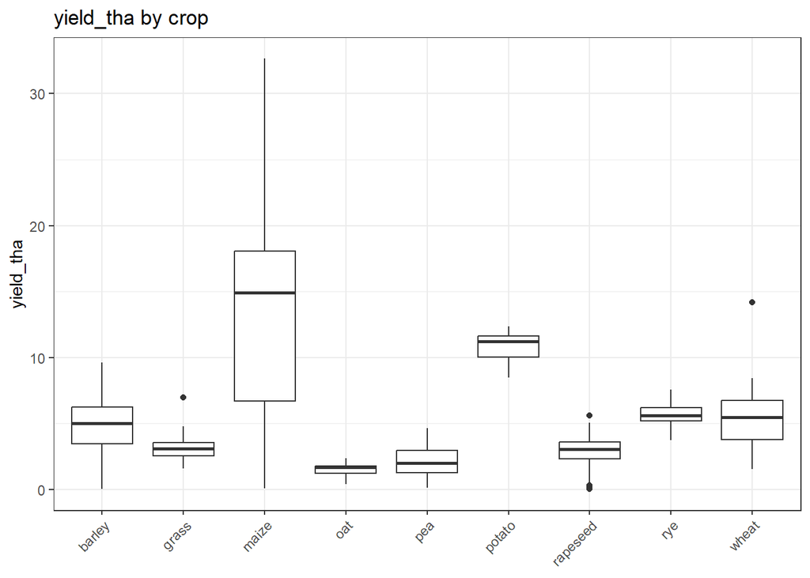

```r
ggplot(df, aes(x = crop_unified, y = yield_tha)) +
  geom_boxplot() +
  theme_bw() +
  labs(title = "yield_tha by crop", x = NULL) +
  theme(axis.text.x = element_text(angle = 45, hjust = 1))
```

It is clear that the maize has a completely different scale of yield within the dataset. It is because in comparision to all the other crops sillage maize is produced only to feed the animals and hence the whole biomass is harvested and not only the grain as it is for all the other crops. Hence, the yield is on a different scale and all teh yield in the dataset has to be scaled in order for the results to be interpretable and consistent across crops.

## Zero-inflation

```r
sapply(df[num_vars], function(x) mean(x == 0, na.rm = TRUE))
```

```
##               prop_swf               l_contag                   l_np
##            0.012979488            0.000000000            0.000000000
##                 l_sidi                 l_shdi                   l_ai
##            0.000000000            0.000000000            0.000000000
##                   l_ed distance_to_tree_strip            temp_C_mean
##            0.000000000            0.000000000            0.000000000
##         sun_MJ_m2_mean          precip_mm_sum                   clay
##            0.000000000            0.000000000            0.000000000
##                   sand                   silt             mean_slope
##            0.000000000            0.000000000            0.000000000
##              min_slope              max_slope        prop_swf_within
##            0.077876927            0.000000000            0.010293361
##                 fert_N                treeage                  AFage
##            0.282557508            0.133310156            0.006953297
##                   area
##            0.000000000
```

Fertilization and the proportion of small woody features in the dataset are zero infliated a bit due to the fact that - for fertilization not all the fertilization management could be found for all fields only for a part of them - for prop of small woofy features sometimes there was no swf present in the buffer which is also fine and to be expected. - treeage sometimes is zero when the system just started or was harvested - AFage is zero when the system just harvested

## Collinearity among scalar predictors

```r
cor_mat <- df |>
  select(all_of(num_vars)) |>
  cor(use = "pairwise.complete.obs")

round(cor_mat, 2)
```

```
##                        prop_swf l_contag  l_np l_sidi l_shdi  l_ai  l_ed
## prop_swf                   1.00    -0.41 -0.01   0.11   0.03 -0.15  0.15
## l_contag                  -0.41     1.00  0.01  -0.53  -0.39  0.34 -0.34
## l_np                      -0.01     0.01  1.00   0.24   0.39 -0.75  0.76
## l_sidi                     0.11    -0.53  0.24   1.00   0.97 -0.34  0.37
## l_shdi                     0.03    -0.39  0.39   0.97   1.00 -0.41  0.45
## l_ai                      -0.15     0.34 -0.75  -0.34  -0.41  1.00 -1.00
## l_ed                       0.15    -0.34  0.76   0.37   0.45 -1.00  1.00
## distance_to_tree_strip    -0.07     0.06  0.10   0.01   0.06 -0.14  0.14
## temp_C_mean               -0.03    -0.08 -0.56  -0.20  -0.29  0.61 -0.62
## sun_MJ_m2_mean            -0.07     0.10 -0.37  -0.21  -0.21  0.43 -0.43
## precip_mm_sum              0.06    -0.19  0.49   0.28   0.31 -0.65  0.65
## clay                      -0.21     0.32  0.35   0.16   0.32 -0.42  0.43
## sand                       0.10    -0.20 -0.36  -0.14  -0.28  0.40 -0.41
## silt                      -0.01     0.09  0.32   0.11   0.22 -0.33  0.33
## mean_slope                 0.20    -0.49  0.32   0.65   0.65 -0.66  0.68
## min_slope                  0.27    -0.54  0.45   0.60   0.58 -0.85  0.85
## max_slope                 -0.10    -0.10 -0.31   0.44   0.43  0.35 -0.32
## prop_swf_within            0.36    -0.22 -0.17  -0.47  -0.59 -0.41  0.36
## fert_N                    -0.19     0.15 -0.30  -0.08  -0.08  0.45 -0.46
## treeage                   -0.18     0.52 -0.29  -0.50  -0.46  0.62 -0.62
## AFage                     -0.26     0.50 -0.08  -0.06   0.08  0.25 -0.23
## area                      -0.34     0.74 -0.16  -0.51  -0.41  0.65 -0.65
##                        distance_to_tree_strip temp_C_mean sun_MJ_m2_mean
## prop_swf                                -0.07       -0.03          -0.07
## l_contag                                 0.06       -0.08           0.10
## l_np                                     0.10       -0.56          -0.37
## l_sidi                                   0.01       -0.20          -0.21
## l_shdi                                   0.06       -0.29          -0.21
## l_ai                                    -0.14        0.61           0.43
## l_ed                                     0.14       -0.62          -0.43
## distance_to_tree_strip                   1.00       -0.09           0.03
## temp_C_mean                             -0.09        1.00           0.82
## sun_MJ_m2_mean                           0.03        0.82           1.00
## precip_mm_sum                            0.11       -0.77          -0.82
## clay                                     0.17       -0.46          -0.13
## sand                                    -0.10        0.45           0.15
## silt                                     0.04       -0.39          -0.15
## mean_slope                               0.07       -0.44          -0.29
## min_slope                                0.08       -0.48          -0.34
```

[output cut: 37 more lines]

```
## distance_to_tree_strip      0.01           -0.04   0.09   -0.07  0.22 -0.06
## temp_C_mean                 0.15           -0.18  -0.08    0.22  0.03  0.23
## sun_MJ_m2_mean              0.13           -0.25  -0.13    0.20  0.34  0.29
## precip_mm_sum              -0.17            0.32   0.14   -0.40 -0.17 -0.55
## clay                        0.24           -0.10  -0.12   -0.07  0.47  0.04
## sand                       -0.33            0.00   0.23   -0.03 -0.31 -0.11
## silt                        0.35            0.06  -0.27    0.10  0.16  0.16
## mean_slope                  0.37            0.19  -0.18   -0.52 -0.11 -0.63
## min_slope                  -0.03            0.35  -0.30   -0.70 -0.29 -0.82
## max_slope                   1.00           -0.31   0.35    0.14  0.37  0.13
## prop_swf_within            -0.31            1.00  -0.07   -0.04 -0.46 -0.42
## fert_N                      0.35           -0.07   1.00    0.13  0.25  0.12
## treeage                     0.14           -0.04   0.13    1.00  0.35  0.77
## AFage                       0.37           -0.46   0.25    0.35  1.00  0.42
## area                        0.13           -0.42   0.12    0.77  0.42  1.00
```

[output not shown]

### Interpretation Summary

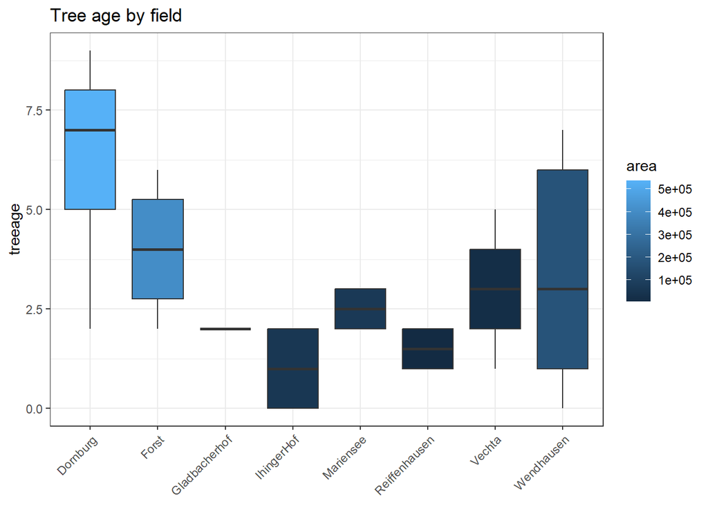

```r
ggplot(df, aes(x = field, y = treeage, fill = area)) +
  geom_boxplot() +
  theme_bw() +
  labs(title = "Tree age by field", x = NULL) +
  theme(axis.text.x = element_text(angle = 45, hjust = 1))
```

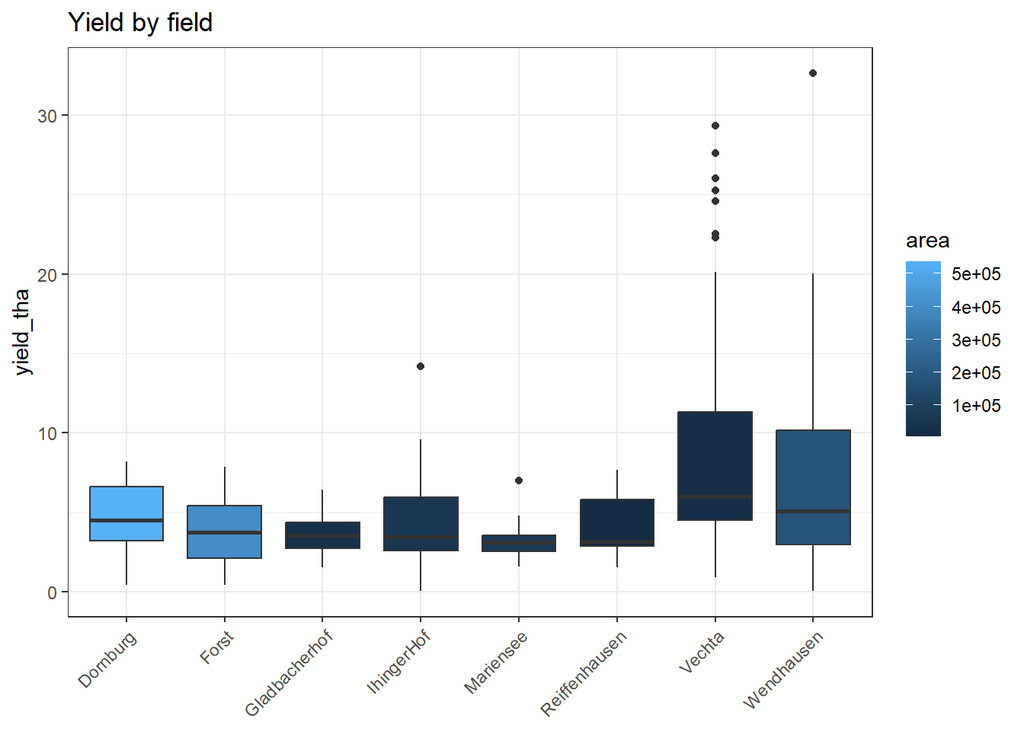

```r
ggplot(df, aes(x = field, y = yield_tha, fill = area)) +
  geom_boxplot() +
  theme_bw() +
  labs(title = "Yield by field", x = NULL) +
  theme(axis.text.x = element_text(angle = 45, hjust = 1))
```

## Relationships between yield and candidate predictors

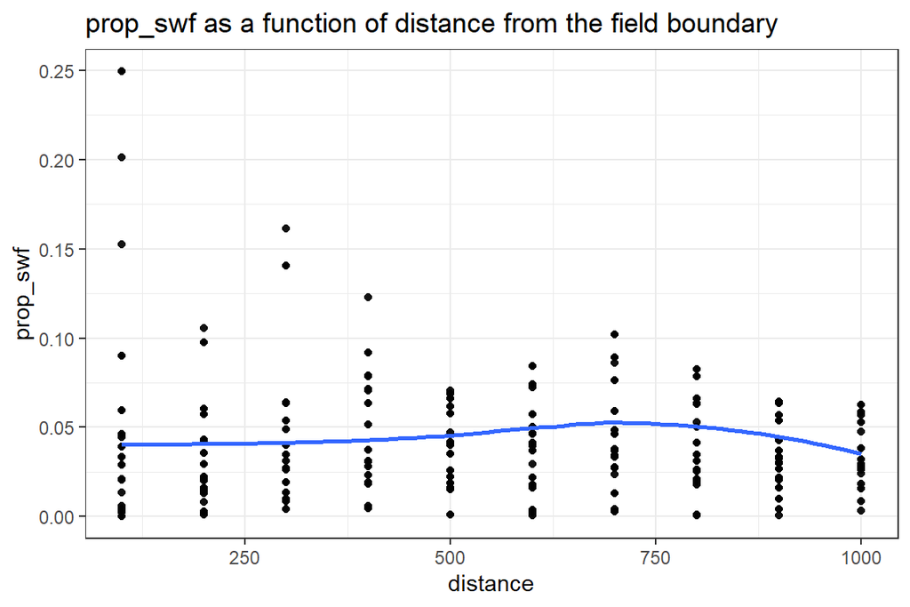

```r
df |>
  select(id, distance, prop_swf) |>
  distinct() |>
  ggplot(aes(x = distance, y = prop_swf)) +
  geom_point(alpha = 0.2) +
  geom_smooth(method = "loess", se = FALSE) +
  theme_bw() +
  labs(title = "prop_swf as a function of distance from the field boundary")
```

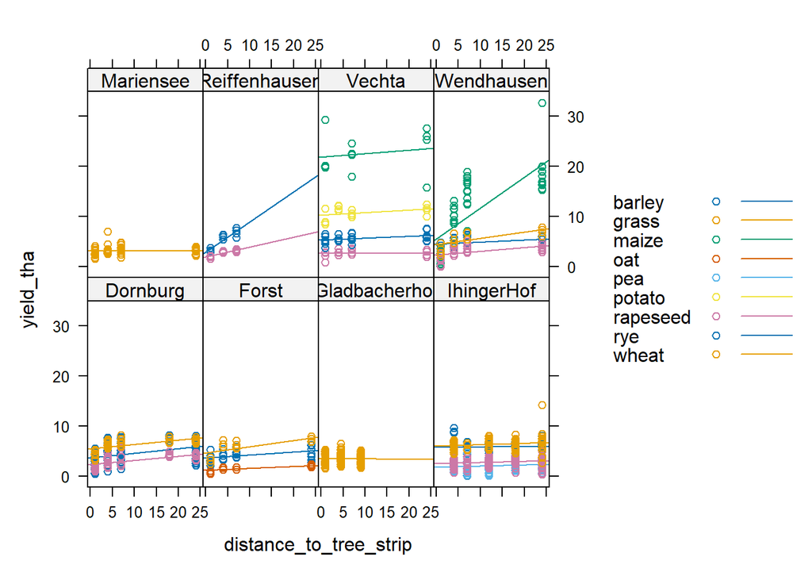

```r
my.yield <- df |>
  distinct(id, field, year, yield_tha, distance_to_tree_strip, crop_unified,
           fert_N, treeage) |>
  mutate(field = factor(field), crop_unified = factor(crop_unified), year = factor(year))

xyplot(yield_tha ~ distance_to_tree_strip | field, groups = crop_unified,
       data = my.yield, type = c("p", "r"), auto.key = TRUE)
```

# (4) Model Run

## Building the scalar (numerical) predictors dataset

Based on the collinearity analysis above some variables were exluded. Yield_th was scaled.

```r
predictors <- df |>
  mutate(yield_scaled = scale(yield_tha)) |>
  distinct(id, field, year, yield_scaled, distance_to_tree_strip,
           crop_unified, fert_N, temp_C_mean, sun_MJ_m2_mean,
           precip_mm_sum, l_shdi, l_contag, l_ed,
           treeage, AFage,
           prop_swf_within, clay, latitude, longitude) |>
  filter(id %in% id_order) |>
  slice(match(id_order, id))

stopifnot(nrow(predictors) == nrow(swf_mat))


predictors$field         <- factor(predictors$field)
predictors$crop_unified  <- factor(predictors$crop_unified)
```

## Adaptive basis dimensions

```r
safe_k <- function(x, k_wanted) {
  min(k_wanted, length(unique(x[!is.na(x)])) - 1)
}

k_dist  <- safe_k(predictors$distance_to_tree_strip, 6)
k_fertN <- safe_k(predictors$fert_N,                 5)
k_temp  <- safe_k(predictors$temp_C_mean,            5)
k_sun   <- safe_k(predictors$sun_MJ_m2_mean,         5)
k_prec  <- safe_k(predictors$precip_mm_sum,          5)
k_shdi  <- safe_k(predictors$l_shdi,                 5)
k_cont  <- safe_k(predictors$l_contag,               5)
k_ed    <- safe_k(predictors$l_ed,                   5)
k_afage    <- safe_k(predictors$AFage,                   5)
k_tree  <- safe_k(predictors$treeage,                5)
```

```r
k_to_check <- list(
  distance_to_tree_strip = k_dist,
  fert_N                 = k_fertN,
  temp_C_mean             = k_temp,
  sun_MJ_m2_mean          = k_sun,
  precip_mm_sum           = k_prec,
  l_shdi                  = k_shdi,
  l_contag                = k_cont,
  l_ed                    = k_ed,
  AFage                   = k_afage,
  treeage                 = k_tree
)

for (nm in names(k_to_check)) {
  k_val <- k_to_check[[nm]]
  n_unique <- length(unique(predictors[[nm]][!is.na(predictors[[nm]])]))
  cat(sprintf("%-25s k=%-3d unique=%-3d ", nm, k_val, n_unique))
  res <- tryCatch({
    smoothCon(s(x, k = k_val), data = data.frame(x = predictors[[nm]]))
    "OK"
  }, error = function(e) paste("FAILS:", conditionMessage(e)))
  cat(res, "\n")
}
```

```
## distance_to_tree_strip    k=6   unique=8   OK
## fert_N                    k=5   unique=24  FAILS: NA/NaN/Inf in foreign function call (arg 1)
## temp_C_mean               k=5   unique=34  OK
## sun_MJ_m2_mean            k=5   unique=34  OK
## precip_mm_sum             k=5   unique=34  OK
## l_shdi                    k=5   unique=30  OK
## l_contag                  k=5   unique=30  OK
## l_ed                      k=5   unique=30  OK
## AFage                     k=5   unique=17  OK
## treeage                   k=5   unique=10  OK
```

## Functional swf predictor

```r
swf_long <- df |>
  dplyr::select(id, field, distance, prop_swf) |>
  unique()

swf_wide <- swf_long |>
  tidyr::pivot_wider(names_from = distance, values_from = prop_swf) |>
  arrange(id)

grid <- as.numeric(names(swf_wide)[-c(1, 2)])
Y_swf <- as.matrix(swf_wide[, -c(1, 2)])
field_id <- df |> distinct(id, field) |> arrange(id) |> pull(field)

swf_model <- pffr(
  Y_swf ~ s(field_id, bs = "re"),
  yind = grid,
  data = list(Y_swf = Y_swf, field_id = factor(field_id)),
  family = binomial()
)

summary(swf_model)
```

[output not shown]

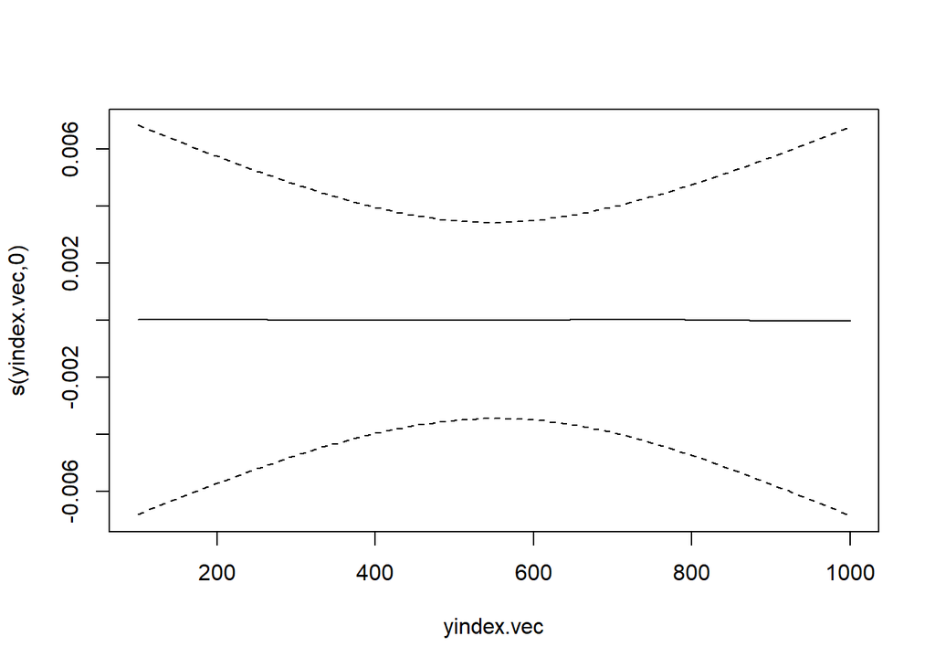

```r
plot(swf_model)
```

## The model

bs (optional): character string indicating the bs for the basis applied to the transformed coordinates; if empty, the appropriate defaults are used.

```r
fitted_swf <- fitted(swf_model)
rownames(fitted_swf) <- swf_wide$id

swf_fitted <- fitted_swf[match(id_order, rownames(fitted_swf)), ]

predictors$swf_fitted <- swf_fitted

model <- pfr(
  yield_scaled ~
    lf(swf_fitted, argvals = grid, bs = "ps", k = 15) +
    s(distance_to_tree_strip, bs = "tp",k = k_dist) +
    s(fert_N,         bs = "tp",k = k_fertN) +
    s(temp_C_mean,    bs = "tp",k = k_temp) +
    s(sun_MJ_m2_mean, bs = "tp",k = k_sun) +
    s(precip_mm_sum,  bs = "tp",k = k_prec) +
    s(l_shdi,         bs = "tp",k = k_shdi) +
    s(l_contag,       bs = "tp",k = k_cont) +
    s(l_ed,           bs = "tp",k = k_ed) +
    s(AFage,          bs = "tp",k = k_afage) +
    s(treeage,        bs = "tp",k = k_tree) +
    crop_unified +
    s(field, bs = "re"),
  data   = predictors,
  family = "gaussian",
  method = "REML"
)

summary(model)
```

```
##
## Family: gaussian
## Link function: identity
##
## Formula:
## yield_scaled ~ s(x = swf_fitted.tmat, by = L.swf_fitted, bs = "ps",
##     k = 15) + s(distance_to_tree_strip, bs = "tp", k = k_dist) +
##     s(fert_N, bs = "tp", k = k_fertN) + s(temp_C_mean, bs = "tp",
##     k = k_temp) + s(sun_MJ_m2_mean, bs = "tp", k = k_sun) + s(precip_mm_sum,
##     bs = "tp", k = k_prec) + s(l_shdi, bs = "tp", k = k_shdi) +
##     s(l_contag, bs = "tp", k = k_cont) + s(l_ed, bs = "tp", k = k_ed) +
##     s(AFage, bs = "tp", k = k_afage) + s(treeage, bs = "tp",
##     k = k_tree) + crop_unified + s(field, bs = "re")
##
## Parametric coefficients:
##                      Estimate Std. Error t value Pr(>|t|)
## (Intercept)           1.05506    0.84148   1.254    0.210
## crop_unifiedgrass    -0.18703    0.35085  -0.533    0.594
## crop_unifiedmaize     0.84409    0.64590   1.307    0.192
## crop_unifiedpotato   -2.63140    0.58424  -4.504 7.97e-06 ***
## crop_unifiedrapeseed -0.97951    0.21296  -4.600 5.14e-06 ***
## crop_unifiedrye      -3.12797    0.48373  -6.466 2.04e-10 ***
## crop_unifiedwheat     0.07261    0.16229   0.447    0.655
## ---
## Signif. codes:  0 '***' 0.001 '**' 0.01 '*' 0.05 '.' 0.1 ' ' 1
##
## Approximate significance of smooth terms:
##                                       edf Ref.df      F  p-value
## s(swf_fitted.tmat):L.swf_fitted 2.9059540  2.978  7.243    8e-05 ***
## s(distance_to_tree_strip)       4.7570986  4.959 43.623  < 2e-16 ***
## s(fert_N)                       2.2585604  2.771  1.094 0.271606
## s(temp_C_mean)                  2.1811279  2.528  6.426 0.003133 **
## s(sun_MJ_m2_mean)               3.2124131  3.551  6.204 0.000119 ***
## s(precip_mm_sum)                1.0000026  1.000  4.055 0.044463 *
## s(l_shdi)                       1.0000101  1.000  1.033 0.309877
## s(l_contag)                     1.0000015  1.000  1.685 0.194685
## s(l_ed)                         1.0000370  1.000  6.865 0.008999 **
## s(AFage)                        1.0000029  1.000  0.226 0.634423
## s(treeage)                      1.0001770  1.000  1.583 0.208857
## s(field)                        0.0002572  3.000  0.000 0.786282
## ---
## Signif. codes:  0 '***' 0.001 '**' 0.01 '*' 0.05 '.' 0.1 ' ' 1
##
## R-sq.(adj) =  0.754   Deviance explained = 76.4%
## -REML = 667.55  Scale est. = 0.40569   n = 647
```

```r
summary(model)$r.sq
```

```
## [1] 0.7538834
```

```r
summary(model)$dev.expl
```

```
## [1] 0.7642903
```

```r
AIC(model)
```

```
## [1] 1285.026
```

```r
#gam.check(model)
```

```r
model2 <- pfr(
  yield_scaled ~
    lf(swf_mat, argvals = grid, bs = "ps", k = 15) +
    s(distance_to_tree_strip, bs = "tp",k = k_dist) +
    s(fert_N,         bs = "tp",k = k_fertN) +
    s(temp_C_mean,    bs = "tp",k = k_temp) +
    s(sun_MJ_m2_mean, bs = "tp",k = k_sun) +
    s(precip_mm_sum,  bs = "tp",k = k_prec) +
    s(l_shdi,         bs = "tp",k = k_shdi) +
    s(l_contag,       bs = "tp",k = k_cont) +
    s(l_ed,           bs = "tp",k = k_ed) +
    s(AFage,          bs = "tp",k = k_afage) +
    s(treeage,        bs = "tp",k = k_tree) +
    crop_unified +
    s(field, bs = "re"),
  data   = predictors,
  family = "gaussian",
  method = "REML"
)
```

```r
model3 <- pfr(
  yield_scaled ~
    lf(swf_mat, argvals = grid, bs = "ps", k = 15) +
    s(distance_to_tree_strip, bs = "tp",k = k_dist) +
    crop_unified +
    s(field, bs = "re"),
  data   = predictors,
  family = "gaussian",
  method = "REML"
)

summary(model3)
```

```
##
## Family: gaussian
## Link function: identity
##
## Formula:
## yield_scaled ~ s(x = swf_mat.tmat, by = L.swf_mat, bs = "ps",
##     k = 15) + s(distance_to_tree_strip, bs = "tp", k = k_dist) +
##     crop_unified + s(field, bs = "re")
##
## Parametric coefficients:
##                      Estimate Std. Error t value Pr(>|t|)
## (Intercept)          -0.44062    0.64513  -0.683   0.4948
## crop_unifiedgrass     0.80960    1.85311   0.437   0.6623
## crop_unifiedmaize     1.96747    0.11631  16.916  < 2e-16 ***
## crop_unifiedoat      -0.69192    0.41490  -1.668   0.0956 .
## crop_unifiedpea      -1.02812    0.22613  -4.547 6.03e-06 ***
## crop_unifiedpotato    1.73892    0.20489   8.487  < 2e-16 ***
## crop_unifiedrapeseed -0.73545    0.05857 -12.557  < 2e-16 ***
## crop_unifiedrye       0.15805    0.18229   0.867   0.3861
## crop_unifiedwheat     0.34557    0.05762   5.997 2.69e-09 ***
## ---
## Signif. codes:  0 '***' 0.001 '**' 0.01 '*' 0.05 '.' 0.1 ' ' 1
##
## Approximate significance of smooth terms:
##                             edf Ref.df     F p-value
## s(swf_mat.tmat):L.swf_mat 6.391  6.905 32.28  <2e-16 ***
## s(distance_to_tree_strip) 4.755  4.965 50.34  <2e-16 ***
## s(field)                  5.873  6.000 50.86  <2e-16 ***
## ---
## Signif. codes:  0 '***' 0.001 '**' 0.01 '*' 0.05 '.' 0.1 ' ' 1
##
## R-sq.(adj) =  0.726   Deviance explained = 73.2%
## -REML = 1036.1  Scale est. = 0.31237   n = 1171
```

```r
summary(model3)$r.sq
```

```
## [1] 0.7257838
```

```r
summary(model3)$dev.expl
```

```
## [1] 0.7316475
```

```r
AIC(model3)
```

```
## [1] 1989.994
```

```r
model4 <- pfr(
  yield_scaled ~
    af(swf_mat, argvals = grid, Qtransform=TRUE, k=c(7,7)) +
    s(distance_to_tree_strip, bs = "tp",k = k_dist) +
    s(fert_N,         bs = "tp",k = k_fertN) +
    s(temp_C_mean,    bs = "tp",k = k_temp) +
    s(sun_MJ_m2_mean, bs = "tp",k = k_sun) +
    s(precip_mm_sum,  bs = "tp",k = k_prec) +
    s(l_shdi,         bs = "tp",k = k_shdi) +
    s(l_contag,       bs = "tp",k = k_cont) +
    s(l_ed,           bs = "tp",k = k_ed) +
    s(AFage,          bs = "tp",k = k_afage) +
    s(treeage,        bs = "tp",k = k_tree) +
    crop_unified +
    s(field, bs = "re"),
  data   = predictors,
  family = "gaussian",
  method = "REML"
)

summary(model4)
```

```
##
## Family: gaussian
## Link function: identity
##
## Formula:
## yield_scaled ~ s(z = swf_mat.tmat, x = swf_mat.omat, by = L.swf_mat,
##     k = c(7, 7), bs = "dt", xt = list(tf = list(swf_mat.omat = "QTransform"),
##         basistype = "te")) + s(distance_to_tree_strip, bs = "tp",
##     k = k_dist) + s(fert_N, bs = "tp", k = k_fertN) + s(temp_C_mean,
##     bs = "tp", k = k_temp) + s(sun_MJ_m2_mean, bs = "tp", k = k_sun) +
##     s(precip_mm_sum, bs = "tp", k = k_prec) + s(l_shdi, bs = "tp",
##     k = k_shdi) + s(l_contag, bs = "tp", k = k_cont) + s(l_ed,
##     bs = "tp", k = k_ed) + s(AFage, bs = "tp", k = k_afage) +
##     s(treeage, bs = "tp", k = k_tree) + crop_unified + s(field,
##     bs = "re")
##
## Parametric coefficients:
##                      Estimate Std. Error t value Pr(>|t|)
## (Intercept)           0.00000    0.00000     NaN      NaN
## crop_unifiedgrass    -0.19817    0.31374  -0.632 0.527852
## crop_unifiedmaize     2.44426    0.23492  10.405  < 2e-16 ***
## crop_unifiedpotato   -1.45376    0.36187  -4.017 6.61e-05 ***
## crop_unifiedrapeseed -1.02500    0.13402  -7.648 7.79e-14 ***
## crop_unifiedrye      -1.72396    0.45111  -3.822 0.000146 ***
## crop_unifiedwheat    -0.05672    0.13758  -0.412 0.680295
## ---
## Signif. codes:  0 '***' 0.001 '**' 0.01 '*' 0.05 '.' 0.1 ' ' 1
##
## Approximate significance of smooth terms:
##                                               edf Ref.df      F  p-value
## te(swf_mat.tmat,swf_mat.omat):L.swf_mat 4.7622819  5.457  8.063  < 2e-16 ***
## s(distance_to_tree_strip)               4.7604935  4.960 43.427  < 2e-16 ***
## s(fert_N)                               1.0001796  1.000 14.294 0.000172 ***
## s(temp_C_mean)                          1.0001694  1.000 19.490 1.24e-05 ***
## s(sun_MJ_m2_mean)                       1.1777116  1.319 36.087  < 2e-16 ***
## s(precip_mm_sum)                        1.0000367  1.000 15.826 7.78e-05 ***
## s(l_shdi)                               1.0000608  1.000 30.021  < 2e-16 ***
## s(l_contag)                             1.0001344  1.000  6.466 0.011232 *
## s(l_ed)                                 1.0000156  1.000  0.273 0.601832
## s(AFage)                                1.0000119  1.000  1.666 0.197324
## s(treeage)                              1.0000249  1.000  6.354 0.011961 *
## s(field)                                0.0004489  5.000  0.000 0.447384
## ---
## Signif. codes:  0 '***' 0.001 '**' 0.01 '*' 0.05 '.' 0.1 ' ' 1
##
## Rank: 102/103
## R-sq.(adj) =  0.753   Deviance explained = 76.2%
## -REML = 672.01  Scale est. = 0.40725   n = 647
```

```r
summary(model4)$r.sq
```

```
## [1] 0.7529338
```

```r
summary(model4)$dev.expl
```

```
## [1] 0.7619986
```

```r
AIC(model4)
```

```
## [1] 1283.185
```

```r
model5 <- pfr(
  yield_scaled ~
    lf(swf_fitted, argvals = grid, bs = "ps", k = 15) +
    s(distance_to_tree_strip, bs = "tp",k = k_dist) +
    te(longitude, latitude, bs = c("tp", "tp"), k = c(5, 5)) +
    fert_N + treeage + crop_unified +

    s(field, bs = "re"),
  data   = predictors,
  family = "gaussian",
  method = "REML"
)

summary(model5)
```

```
##
## Family: gaussian
## Link function: identity
##
## Formula:
## yield_scaled ~ s(x = swf_fitted.tmat, by = L.swf_fitted, bs = "ps",
##     k = 15) + s(distance_to_tree_strip, bs = "tp", k = k_dist) +
##     te(longitude, latitude, bs = c("tp", "tp"), k = c(5, 5)) +
##     fert_N + treeage + crop_unified + s(field, bs = "re")
##
## Parametric coefficients:
##                       Estimate Std. Error t value Pr(>|t|)
## (Intercept)          -3.248035   3.329042  -0.976    0.330
## fert_N                0.003946   0.000822   4.800 1.98e-06 ***
## treeage               0.026361   0.017992   1.465    0.143
## crop_unifiedgrass    -0.480704   2.477791  -0.194    0.846
## crop_unifiedmaize     2.004664   0.153768  13.037  < 2e-16 ***
## crop_unifiedpotato   -1.658435   0.308176  -5.381 1.04e-07 ***
## crop_unifiedrapeseed -0.707808   0.105892  -6.684 5.13e-11 ***
## crop_unifiedrye      -3.443182   0.286380 -12.023  < 2e-16 ***
## crop_unifiedwheat     0.174257   0.106300   1.639    0.102
## ---
## Signif. codes:  0 '***' 0.001 '**' 0.01 '*' 0.05 '.' 0.1 ' ' 1
##
## Approximate significance of smooth terms:
##                                       edf Ref.df      F p-value
## s(swf_fitted.tmat):L.swf_fitted 2.000e+00  2.000  0.845   0.430
## s(distance_to_tree_strip)       4.739e+00  4.952 40.766  <2e-16 ***
## te(longitude,latitude)          3.000e+00  3.000  0.439   0.725
## s(field)                        1.289e-15  5.000  0.000  <2e-16 ***
## ---
## Signif. codes:  0 '***' 0.001 '**' 0.01 '*' 0.05 '.' 0.1 ' ' 1
##
## R-sq.(adj) =  0.732   Deviance explained = 73.9%
## -REML = 682.53  Scale est. = 0.44215   n = 647
```

```r
summary(model5)$r.sq
```

```
## [1] 0.731764
```

```r
summary(model5)$dev.expl
```

```
## [1] 0.7391295
```

```r
AIC(model5)
```

```
## [1] 1328.975
```

```r
model6 <- pfr(
  yield_scaled ~
    lf(swf_fitted, argvals = grid, bs = "ps", k = 15) +
    s(distance_to_tree_strip, bs = "tp",k = k_dist) +
    te(temp_C_mean, precip_mm_sum, bs = c("tp", "tp"), k = c(5, 5)) +
    fert_N + treeage + crop_unified +

    s(field, bs = "re"),
  data   = predictors,
  family = "gaussian",
  method = "REML"
)

summary(model6)
```

```
##
## Family: gaussian
## Link function: identity
##
## Formula:
## yield_scaled ~ s(x = swf_fitted.tmat, by = L.swf_fitted, bs = "ps",
##     k = 15) + s(distance_to_tree_strip, bs = "tp", k = k_dist) +
##     te(temp_C_mean, precip_mm_sum, bs = c("tp", "tp"), k = c(5,
##         5)) + fert_N + treeage + crop_unified + s(field, bs = "re")
##
## Parametric coefficients:
##                        Estimate Std. Error t value Pr(>|t|)
## (Intercept)           2.1137892  0.3456939   6.115 1.71e-09 ***
## fert_N                0.0015109  0.0009658   1.564   0.1182
## treeage              -0.0519468  0.0228856  -2.270   0.0236 *
## crop_unifiedgrass    -0.5285739  0.3449012  -1.533   0.1259
## crop_unifiedmaize     1.2352579  0.5901746   2.093   0.0368 *
## crop_unifiedpotato   -0.6990743  0.7113602  -0.983   0.3261
## crop_unifiedrapeseed -1.0916979  0.1335734  -8.173 1.69e-15 ***
## crop_unifiedrye      -2.5540488  0.3619755  -7.056 4.59e-12 ***
## crop_unifiedwheat     0.0992517  0.1539313   0.645   0.5193
## ---
## Signif. codes:  0 '***' 0.001 '**' 0.01 '*' 0.05 '.' 0.1 ' ' 1
##
## Approximate significance of smooth terms:
##                                       edf Ref.df     F p-value
## s(swf_fitted.tmat):L.swf_fitted 2.2430173  2.398 38.27  <2e-16 ***
## s(distance_to_tree_strip)       4.7631209  4.961 44.29  <2e-16 ***
## te(temp_C_mean,precip_mm_sum)   9.7236141 11.063 10.49  <2e-16 ***
## s(field)                        0.0007279  3.000  0.00   0.505
## ---
## Signif. codes:  0 '***' 0.001 '**' 0.01 '*' 0.05 '.' 0.1 ' ' 1
##
## R-sq.(adj) =  0.754   Deviance explained = 76.4%
## -REML = 664.64  Scale est. = 0.4047    n = 647
```

```r
summary(model6)$r.sq
```

```
## [1] 0.7544843
```

```r
summary(model6)$dev.expl
```

```
## [1] 0.7638832
```

```r
AIC(model6)
```

```
## [1] 1281.412
```

```r
model7 <- pfr(
  yield_scaled ~
    lf(swf_fitted, argvals = grid, bs = "ps", k = 15) +
    s(distance_to_tree_strip, bs = "tp",k = k_dist) +
    te(temp_C_mean, precip_mm_sum, fert_N, treeage, bs = c("tp","tp","tp", "tp"), k = c(5, 5, 5, 5)) +
    crop_unified +
    s(field, bs = "re"),
  data   = predictors,
  family = "gaussian",
  method = "REML"
)

summary(model7)
```

```
##
## Family: gaussian
## Link function: identity
##
## Formula:
## yield_scaled ~ s(x = swf_fitted.tmat, by = L.swf_fitted, bs = "ps",
##     k = 15) + s(distance_to_tree_strip, bs = "tp", k = k_dist) +
##     te(temp_C_mean, precip_mm_sum, fert_N, treeage, bs = c("tp",
##         "tp", "tp", "tp"), k = c(5, 5, 5, 5)) + crop_unified +
##     s(field, bs = "re")
##
## Parametric coefficients:
##                      Estimate Std. Error t value Pr(>|t|)
## (Intercept)            0.8890     0.9303   0.956  0.33967
## crop_unifiedgrass      0.1996     1.1984   0.167  0.86778
## crop_unifiedmaize      0.2326     1.0471   0.222  0.82429
## crop_unifiedpotato    -2.5245     1.8274  -1.381  0.16765
## crop_unifiedrapeseed  -1.0962     0.3380  -3.243  0.00125 **
## crop_unifiedrye       -3.2791     1.2632  -2.596  0.00966 **
## crop_unifiedwheat      0.2217     0.2320   0.956  0.33961
## ---
## Signif. codes:  0 '***' 0.001 '**' 0.01 '*' 0.05 '.' 0.1 ' ' 1
##
## Approximate significance of smooth terms:
##                                                    edf Ref.df      F p-value
## s(swf_fitted.tmat):L.swf_fitted              2.000e+00  2.000  5.925 0.00283
## s(distance_to_tree_strip)                    4.752e+00  4.957 43.258 < 2e-16
## te(temp_C_mean,precip_mm_sum,fert_N,treeage) 1.987e+01 21.009  7.714 < 2e-16
## s(field)                                     8.726e-05  3.000  0.000 0.12825
##
## s(swf_fitted.tmat):L.swf_fitted              **
## s(distance_to_tree_strip)                    ***
## te(temp_C_mean,precip_mm_sum,fert_N,treeage) ***
## s(field)
## ---
## Signif. codes:  0 '***' 0.001 '**' 0.01 '*' 0.05 '.' 0.1 ' ' 1
##
## R-sq.(adj) =  0.753   Deviance explained = 76.5%
## -REML = 618.72  Scale est. = 0.40763   n = 647
```

```r
summary(model7)$r.sq
```

```
## [1] 0.7527039
```

```r
summary(model7)$dev.expl
```

```
## [1] 0.765191
```

```r
AIC(model7)
```

```
## [1] 1292.906
```